# ¿Qué explica el nivel de desempleo?

Angela Luyo Ramirez

### Introducción

La pandemia por COVID-19 ha tenido impactos no solo económicos, sino tambien sociales, económicos y culturales alrededor del mundo. Desde los primeros casos en el 2019 hasta la fecha, todavía se viven los efectos estructurales de esta crisis, condicionando el nivel de desarrollo y dismimuyendo las posibilidades de subsistencia de la población.Esta situación es comprobada por la Organización Internacional del Trabajo, ya que en uno de sus informes senaló que se perdió el 8,8% de las horas de trabajo a nivel mundial en el 2020 con respecto al año anterior, siendo equivalentes a 255 millones de empleos a tiempo completo.Por estas razones, el presente análisis tomará en cuenta 3 variables independientes que pretenden explicar la dependencia del desempleo a nivel mundial.

Por un lado, se considera la ubicación geográfica de la población en área rural en tanto su situación se ve condicionada por el limitado acceso a recursos básicos como agua, luz, desague, e incluso a oportunidades como educación. Estas consideraciones son indispensables si se busca hablar de desempleo. Por otro lado, dado que la pandemia y el posterior confinamiento limitaron las oportunidades de empleo, las actividades se trasladaron al mundo virtual, resaltando el uso de dispositivos electrónicos en el día a día. Entonces, el acceso a electricidad se volvió vital no solo para continuar trabajando, sino para encontrar trabajo. Por último, se considera el nivel de pobreza como un factor relacionado a los niveles de desempleo, ya que el limitado desarrollo económico durante la pandemia ha tenido gran impacto en los índices de desempleo, comprometiendo la calidad de vida, la satisfacción de las necesidades básicas, y contribuyendo a la vez al aumento de la informalidad laboral.

Es por ello que este trabajo cuenta con relevancia académica, temporal y social al buscar explicar el nivel de desempleo alrededor del mundo durante el año 2020 en base a factores como la cantidad de personas que viven en el sector rural, el acceso a electricidad y el nivel de pobreza.

### Primera parte:Diagnósticos de regresión

Entonces, se puede decir que los niveles de desempleo en los países del mundo responden a la cantidad de población habitante de zonas rurales, lo cual condicionaría su situación socioeconómica (alfabetización, educación, acceso a recursos básicos, etc.)

Ahora bien, con el fin de comprobar la elección del Modelo 1, se realizó una prueba ANOVA entre el modelo de regresión 1 y 5, obteniendo lo siguientes:

- H0: El modelo de regresión no es válido
- H1: El modelo de regresión es válido (variable X aporta al modelo)

La comparación de modelos 1 y 5, usando la tabla de análisis de varianza (anova), propone como hipótesis nula que los modelos no difieren (no se ha reducido el error al pasar de un modelo a otro). Como la comparación no es significativa (vea el Pr(>F)), aceptamos la igualdad de modelos. Entonces, como el p > 0.05 entonces aceptamos la H0, por lo que concluimos que el modelo 5 no es válido como modelo de predición, es decir, existe no una relación lineal entre desempleo, población rural y electricidad.

En segundo lugar, en cuanto a los diagnósticos de regresión, se aplicaron al Modelo 1 obteniendo los siguientes resultados:

### Segunda parte: Análisis de conglomerados y variables latentes

Tomando como base de datos el merge entre Data sobre Nivel de Desempleo y Tasa de mortalidad en bebés, se determinó que la mejor distrubución de los datos es aplicando estandarización, por lo que el siguiente análisis tomará a los datos normalizados.

En primer lugar, tras un análisis de correlación preliminar, resultó necesario hacer cambios de monotonía, ya que Desempleo tenía una correlación negativa con Poblacion Rural, mortality_rate e incidence_tuberculosis.

En tercer lugar, se pudo obtener que existe un valor mal clusterizado, el cual sería Paraguay.Además, en cuanto a la distribución, gracias a la gráfica en dos dimensiones se puede ver que los grupos no estan bien distribuidos porque los valores por colores estan dispersos unos de otros.

Otro resultado que debe resaltarse es que al hacer la comparación de modelos jeráquicos aglomeración y división, la coincidencia entre los valores de la diagonal muestran que no era necesaria una recodificación.

En suma, se concluye también que al usar un metodo jerárquico como Diana, se opta por una técnica de clusterilización dura, en tanto todo elemento termina siendo parte de un cluster.

En cuarto lugar, en cuanto al análisis factorial exploratorio, al ver pocos bloquees sombreados en rojo, no hay mucha esperanza de obtener un buen análisis factorial. Aun así, la gráfica sobre factores o variables latentes acertó en la determinación de 2 familias en la data obtenida tras el merge.

Sin embargo, la matriz de correlaciones terminó no siendo adecuada para el análisis, ya que, pese a no ser una matriz singular, sí es una matriz identidad. El serlo condiciona fuertemente los resultados posteriores, ya que no solo no se puede redimensionar la data a un menor numero de factores, sino que no se puede hacer un analisis factorial para ver qué tanto aporta cada variable a los factores. En consecuencia, no se puede realizar un analisis confirmatorio efectivo, ya que no se puede ir más allá de la creación del model al no contar con la información previamente obtenida en el EFA.

En base a lo expuesto, se pueden presentar algunas razones por las que los resultados del análisis exploratorio no fueron los esperados:

1. las bases de datos contaban con muchos valores perdidos, por lo que al limpiar la data nos quedamos con pocos datos que procesar.
2. las variables independientes no explican los niveles de desempleo en los países del mundo en el año elegido 2020, por lo que se debieron elegir otras variables en lugar de población rural, acceso a electricidad y niveles de pobreza.
3. la base de donde con la que se hizo el merge,Tasa de mortalidad en bebés, no se relacionó efectivamente con la base de datos inicial, condicionando el análisis y el nivel de correlación entre las variables.

## Diagnósticos de Regresión

```r
#install.packages('Rtools')
library(ggrepel)
library(dbscan)
library(rio)
library(Rmisc)
library (stargazer)
```

```
##  Hlavac, Marek (2022). stargazer: Well-Formatted Regression and Summary Statistics Tables.
```

```
##  R package version 5.2.3. https://CRAN.R-project.org/package=stargazer
```

```r
library(moments)
library(DescTools)
library(BBmisc)
library(cluster)
library(factoextra)
```

```r
library(ggplot2)
library(polycor)
```

–> Importación de Data

```r
#Data: Desempleo en los países del mundo
data="https://github.com/lachicadepurpura/TRABAJO-ESTAD-STICA/blob/main/DESEMPLEO.xls"
library(rio) #Convocamos el paquete
data=import("DESEMPLEO.xls")
```

```r
library(Rmisc)
```

```r
modelo1 = lm(data$Desempleo ~ data$`Poblacion rural`)
summary(modelo1)
```

```
##
## Call:
## lm(formula = data$Desempleo ~ data$`Poblacion rural`)
##
## Residuals:
##    Min     1Q Median     3Q    Max
## -9.424 -3.763 -1.356  1.961 20.671
##
## Coefficients:
##                        Estimate Std. Error t value Pr(>|t|)
## (Intercept)             9.66385    0.75485   12.80   <2e-16 ***
## data$`Poblacion rural` -0.03414    0.01641   -2.08   0.0386 *
## ---
## Signif. codes:  0 '***' 0.001 '**' 0.01 '*' 0.05 '.' 0.1 ' ' 1
##
## Residual standard error: 5.444 on 232 degrees of freedom
##   (32 observations deleted due to missingness)
## Multiple R-squared:  0.01831,    Adjusted R-squared:  0.01408
## F-statistic: 4.327 on 1 and 232 DF,  p-value: 0.0386
```

```r
modelo2 = lm(data$Desempleo ~ data$Electricidad + data$`Poblacion rural`+data$Pobreza)
summary(modelo2)
```

```
##
## Call:
## lm(formula = data$Desempleo ~ data$Electricidad + data$`Poblacion rural` +
##     data$Pobreza)
##
## Residuals:
##    Min     1Q Median     3Q    Max
## -7.547 -2.733 -1.129  1.379 12.461
##
## Coefficients:
##                        Estimate Std. Error t value Pr(>|t|)
## (Intercept)             2.95094   12.61985   0.234    0.817
## data$Electricidad       0.05173    0.10740   0.482    0.635
## data$`Poblacion rural` -0.07168    0.07089  -1.011    0.324
## data$Pobreza            0.12039    0.08185   1.471    0.157
##
## Residual standard error: 4.954 on 20 degrees of freedom
##   (242 observations deleted due to missingness)
## Multiple R-squared:  0.206,  Adjusted R-squared:  0.08687
## F-statistic: 1.729 on 3 and 20 DF,  p-value: 0.1932
```

```r
modelo3 = lm(data$Desempleo  ~ data$Pobreza )
summary(modelo3)
```

```
##
## Call:
## lm(formula = data$Desempleo ~ data$Pobreza)
##
## Residuals:
##    Min     1Q Median     3Q    Max
## -6.422 -2.547 -1.279  1.493 12.438
##
## Coefficients:
##              Estimate Std. Error t value Pr(>|t|)
## (Intercept)   5.40533    2.09197   2.584   0.0169 *
## data$Pobreza  0.12453    0.07806   1.595   0.1249
## ---
## Signif. codes:  0 '***' 0.001 '**' 0.01 '*' 0.05 '.' 0.1 ' ' 1
##
## Residual standard error: 5.018 on 22 degrees of freedom
##   (242 observations deleted due to missingness)
## Multiple R-squared:  0.1037, Adjusted R-squared:  0.06294
## F-statistic: 2.545 on 1 and 22 DF,  p-value: 0.1249
```

```r
modelo4 = lm(data$Desempleo ~ data$Electricidad)
summary(modelo4)
```

```
##
## Call:
## lm(formula = data$Desempleo ~ data$Electricidad)
##
## Residuals:
##    Min     1Q Median     3Q    Max
## -8.238 -3.711 -1.405  1.866 20.949
##
## Coefficients:
##                   Estimate Std. Error t value Pr(>|t|)
## (Intercept)        7.29202    1.31933   5.527  8.7e-08 ***
## data$Electricidad  0.01160    0.01495   0.776    0.439
## ---
## Signif. codes:  0 '***' 0.001 '**' 0.01 '*' 0.05 '.' 0.1 ' ' 1
##
## Residual standard error: 5.475 on 233 degrees of freedom
##   (31 observations deleted due to missingness)
## Multiple R-squared:  0.002576,   Adjusted R-squared:  -0.001705
## F-statistic: 0.6018 on 1 and 233 DF,  p-value: 0.4387
```

```r
modelo5 = lm(data$Desempleo  ~ data$`Poblacion rural` + data$Electricidad) #Modelo sin variable PObreza, que tiene pocos valores
summary(modelo5)
```

```
##
## Call:
## lm(formula = data$Desempleo ~ data$`Poblacion rural` + data$Electricidad)
##
## Residuals:
##    Min     1Q Median     3Q    Max
## -9.486 -3.722 -1.313  2.013 20.632
##
## Coefficients:
##                         Estimate Std. Error t value Pr(>|t|)
## (Intercept)            10.448845   2.077418   5.030 9.86e-07 ***
## data$`Poblacion rural` -0.038398   0.019505  -1.969   0.0502 .
## data$Electricidad      -0.007197   0.017740  -0.406   0.6853
## ---
## Signif. codes:  0 '***' 0.001 '**' 0.01 '*' 0.05 '.' 0.1 ' ' 1
##
## Residual standard error: 5.453 on 231 degrees of freedom
##   (32 observations deleted due to missingness)
## Multiple R-squared:  0.01901,    Adjusted R-squared:  0.01052
## F-statistic: 2.238 on 2 and 231 DF,  p-value: 0.109
```

```r
modelo6 = lm(data$Desempleo  ~ data$`Pobreza` + data$`Poblacion rural`)
summary(modelo6)
```

```
##
## Call:
## lm(formula = data$Desempleo ~ data$Pobreza + data$`Poblacion rural`)
##
## Residuals:
##    Min     1Q Median     3Q    Max
## -7.402 -2.746 -1.460  1.058 12.758
##
## Coefficients:
##                        Estimate Std. Error t value Pr(>|t|)
## (Intercept)             8.84925    2.99713   2.953   0.0076 **
## data$Pobreza            0.10814    0.07636   1.416   0.1714
## data$`Poblacion rural` -0.09052    0.05803  -1.560   0.1337
## ---
## Signif. codes:  0 '***' 0.001 '**' 0.01 '*' 0.05 '.' 0.1 ' ' 1
##
## Residual standard error: 4.862 on 21 degrees of freedom
##   (242 observations deleted due to missingness)
## Multiple R-squared:  0.1968, Adjusted R-squared:  0.1203
## F-statistic: 2.572 on 2 and 21 DF,  p-value: 0.1002
```

# Análisis del Modelo 1

```r
library(stargazer)
reg1=lm(modelo1,data)
stargazer(reg1,type = "text",intercept.bottom = FALSE)
```

```
##
## ===============================================
##                         Dependent variable:
##                     ---------------------------
##                              Desempleo
## -----------------------------------------------
## Constant                     9.664***
##                               (0.755)
##
## `Poblacion rural`            -0.034**
##                               (0.016)
##
## -----------------------------------------------
## Observations                    234
## R2                             0.018
## Adjusted R2                    0.014
## Residual Std. Error      5.444 (df = 232)
## F Statistic            4.327** (df = 1; 232)
## ===============================================
## Note:               *p<0.1; **p<0.05; ***p<0.01
```

#modelo 2

```r
library(stargazer)
reg2=lm(modelo2,data)
stargazer(reg2,type = "text",intercept.bottom = FALSE)
```

```
##
## ===============================================
##                         Dependent variable:
##                     ---------------------------
##                              Desempleo
## -----------------------------------------------
## Constant                       2.951
##                              (12.620)
##
## Electricidad                   0.052
##                               (0.107)
##
## `Poblacion rural`             -0.072
##                               (0.071)
##
## Pobreza                        0.120
##                               (0.082)
##
## -----------------------------------------------
## Observations                    24
## R2                             0.206
## Adjusted R2                    0.087
## Residual Std. Error       4.954 (df = 20)
## F Statistic             1.729 (df = 3; 20)
## ===============================================
## Note:               *p<0.1; **p<0.05; ***p<0.01
```

#Modelo 4

```r
reg4=lm(modelo4,data)
stargazer(reg4,type = "text",intercept.bottom = FALSE)
```

```
##
## ===============================================
##                         Dependent variable:
##                     ---------------------------
##                              Desempleo
## -----------------------------------------------
## Constant                     7.292***
##                               (1.319)
##
## Electricidad                   0.012
##                               (0.015)
##
## -----------------------------------------------
## Observations                    235
## R2                             0.003
## Adjusted R2                   -0.002
## Residual Std. Error      5.475 (df = 233)
## F Statistic             0.602 (df = 1; 233)
## ===============================================
## Note:               *p<0.1; **p<0.05; ***p<0.01
```

```r
library(stargazer)
reg5=lm(modelo5,data)
stargazer(reg5,type = "text",intercept.bottom = FALSE)
```

```
##
## ===============================================
##                         Dependent variable:
##                     ---------------------------
##                              Desempleo
## -----------------------------------------------
## Constant                     10.449***
##                               (2.077)
##
## `Poblacion rural`             -0.038*
##                               (0.020)
##
## Electricidad                  -0.007
##                               (0.018)
##
## -----------------------------------------------
## Observations                    234
## R2                             0.019
## Adjusted R2                    0.011
## Residual Std. Error      5.453 (df = 231)
## F Statistic             2.238 (df = 2; 231)
## ===============================================
## Note:               *p<0.1; **p<0.05; ***p<0.01
```

# Modelo 5

```r
library(stargazer)
reg5=lm(modelo5,data)
stargazer(reg5,type = "text",intercept.bottom = FALSE)
```

```
##
## ===============================================
##                         Dependent variable:
##                     ---------------------------
##                              Desempleo
## -----------------------------------------------
## Constant                     10.449***
##                               (2.077)
##
## `Poblacion rural`             -0.038*
##                               (0.020)
##
## Electricidad                  -0.007
##                               (0.018)
##
## -----------------------------------------------
## Observations                    234
## R2                             0.019
## Adjusted R2                    0.011
## Residual Std. Error      5.453 (df = 231)
## F Statistic             2.238 (df = 2; 231)
## ===============================================
## Note:               *p<0.1; **p<0.05; ***p<0.01
```

```r
#Prueba ANOVA
tanova=anova(reg1,reg5)
stargazer(tanova,type = 'text',summary = F,title = "Table de Análisis de Varianza")
```

```
##
## Table de Análisis de Varianza
## =============================================
##   Res.Df    RSS    Df Sum of Sq   F   Pr(> F)
## ---------------------------------------------
## 1  232   6,874.630
## 2  231   6,869.735 1    4.895   0.165  0.685
## ---------------------------------------------
```

#Linealidad

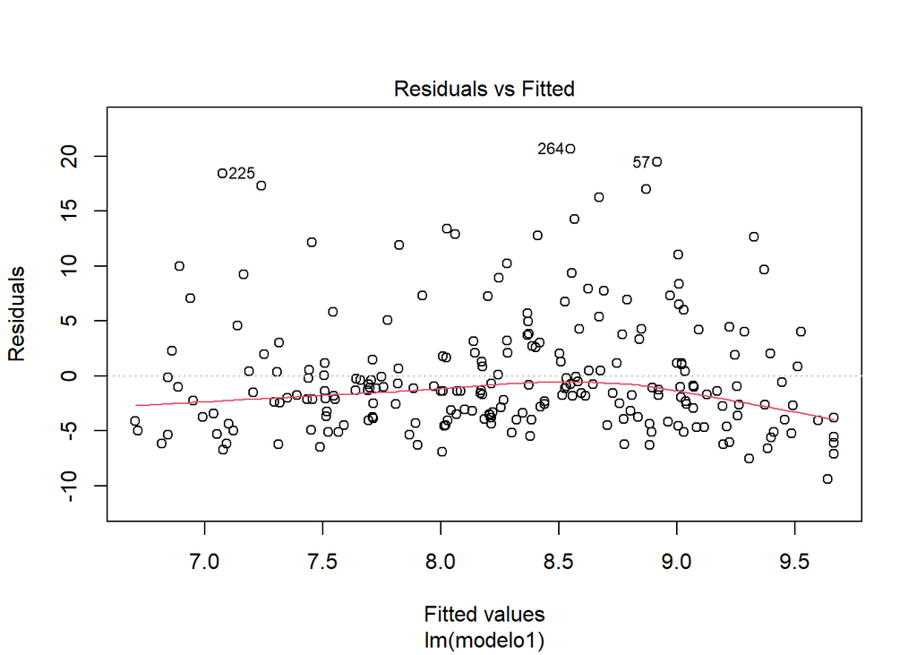

```r
plot(reg1, 1)
```

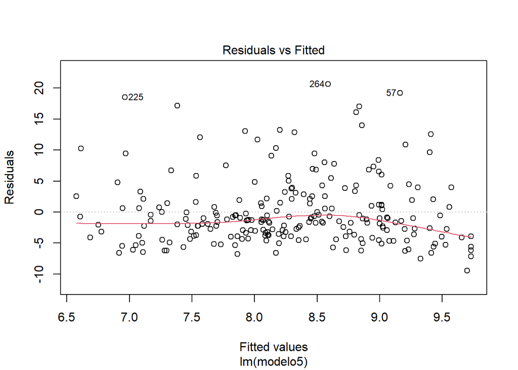

```r
plot(reg5, 1)
```

# Homocedasticidad

La homocedasticidad es una característica de un modelo de regresión lineal que implica que la varianza de los errores es constante a lo largo del tiempo.

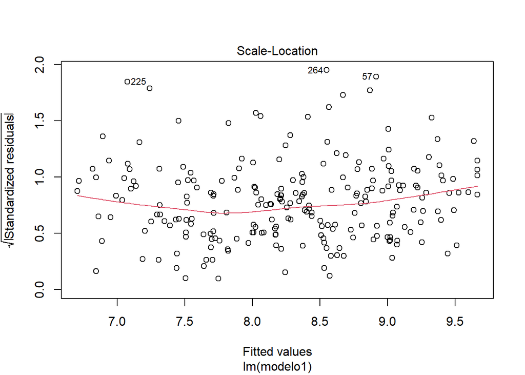

```r
plot(reg1, 3)
```

```r
library(lmtest)
bptest(reg1)
```

```
##
##  studentized Breusch-Pagan test
##
## data:  reg1
## BP = 0.14251, df = 1, p-value = 0.7058
```

# Normalidad de los residuos

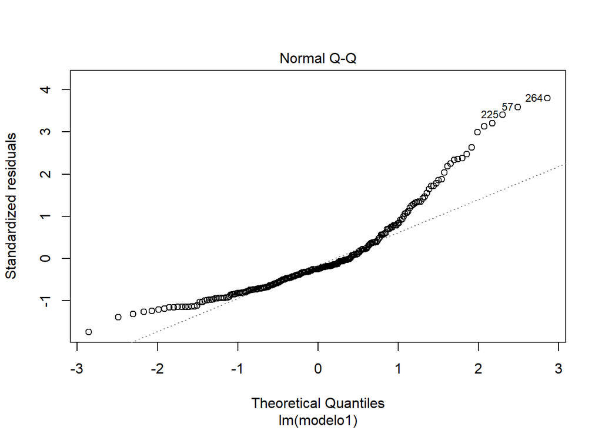

```r
plot(reg1, 2)
```

```r
shapiro.test(reg1$residuals)
```

```
##
##  Shapiro-Wilk normality test
##
## data:  reg1$residuals
## W = 0.87492, p-value = 6.033e-13
```

# NO Multicolinealidad

```r
library(DescTools)
VIF(reg5)  # > 5 es problematico
```

```
## data$`Poblacion rural`      data$Electricidad
##               1.407372               1.407372
```

#valores influyentes

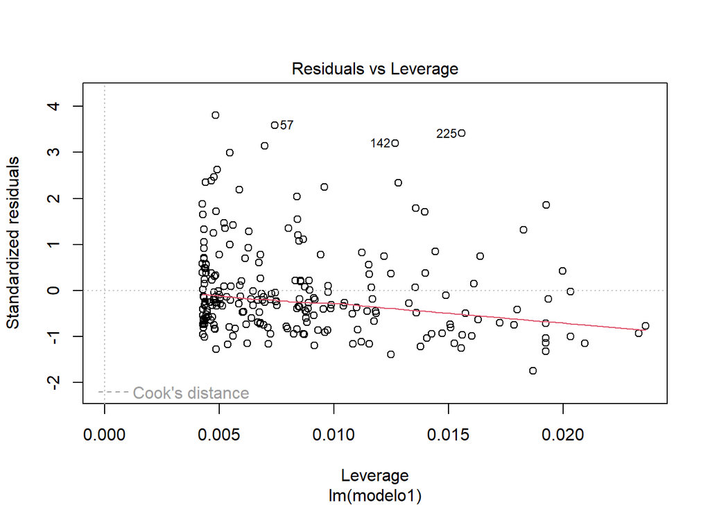

```r
plot(reg1, 5)
```

```r
#Recuperando valores influyentes
checkReg1=as.data.frame(influence.measures(reg1)$is.inf)
head(checkReg1)
```

|  | dfb.1_ | dfb.d$`r | dffit | cov.r | cook.d | hat |
| --- | --- | --- | --- | --- | --- | --- |
| 2 | FALSE | FALSE | FALSE | FALSE | FALSE | FALSE |
| 3 | FALSE | FALSE | FALSE | FALSE | FALSE | FALSE |
| 4 | FALSE | FALSE | FALSE | FALSE | FALSE | FALSE |
| 5 | FALSE | FALSE | FALSE | FALSE | FALSE | FALSE |
| 6 | FALSE | FALSE | FALSE | FALSE | FALSE | FALSE |
| 8 | FALSE | FALSE | FALSE | FALSE | FALSE | FALSE |

```r
checkReg1[checkReg1$cook.d & checkReg1$hat,]
```

| dfb.1_ | dfb.d$`r | dffit | cov.r | cook.d | hat |
| --- | --- | --- | --- | --- | --- |

COnclusiones: Normalmente le prestamos atencion al indice de Cook y a los valores predecidos (los hat values) –> todo FALSO

## Anexos sobre Procesos de Clusterización

```r
#Data
data2="https://github.com/lachicadepurpura/TRABAJO-ESTAD-STICA/blob/main/data_marco.xlsx"
library(rio) #Convocamos el paquete
data2=import("data_marco.xlsx")
```

```r
Datamerge=merge(data,data2,"country")
```

```r
Datemerge = Datamerge[complete.cases(Datamerge$Desempleo),]
Datamerge = Datamerge[complete.cases(Datamerge$Electricidad),]
Datamerge = Datamerge[complete.cases(Datamerge$`Poblacion rural`),]
Datamerge = Datamerge[complete.cases(Datamerge$Pobreza),]
Datamerge = Datamerge[complete.cases(Datamerge$handwashing),]
Datamerge = Datamerge[complete.cases(Datamerge$incidence_tuberculosis),]
Datamerge = Datamerge[complete.cases(Datamerge$mortality_rate),]
```

```r
names(Datamerge)
```

```
## [1] "country"                "Desempleo"              "Electricidad"
## [4] "Poblacion rural"        "Pobreza"                "handwashing"
## [7] "mortality_rate"         "incidence_tuberculosis"
```

#Estrategia Particion

```r
str(Datamerge)
```

```
## 'data.frame':    10 obs. of  8 variables:
##  $ country               : chr  "Armenia" "Bolivia" "Colombia" "Costa Rica" ...
##  $ Desempleo             : num  21.21 7.9 15.04 17.41 6.11 ...
##  $ Electricidad          : num  100 97.6 100 99.9 98.8 ...
##  $ Poblacion rural       : num  36.7 29.9 18.6 19.2 35.8 ...
##  $ Pobreza               : num  27 39 42.5 30 33 21.3 9.8 21.9 27.8 26.9
##  $ handwashing           : num  94.7 26.9 68 85.9 87.2 ...
##  $ mortality_rate        : num  9.7 20.7 11.4 6.7 11.1 8.2 19.5 39.2 13.2 16.2
##  $ incidence_tuberculosis: num  23 105 37 10 48 70 301 425 437 48
```

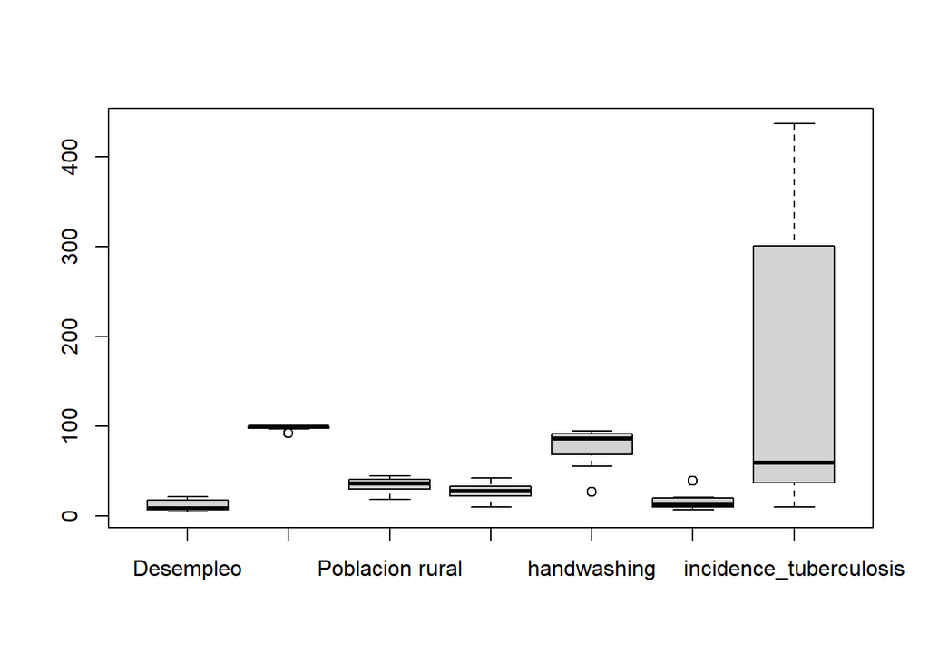

```r
#Verificar distribución
boxplot(Datamerge[,-1])
```

```r
#install.packages('BBmisc')
library(BBmisc)
```

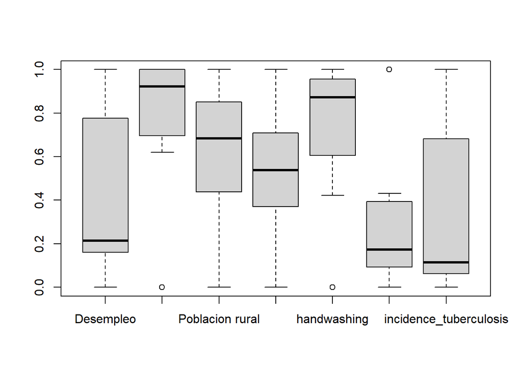

```r
#install.packages('normalize')
boxplot(normalize(Datamerge[,-1],method='range',range=c(0,1)))
```

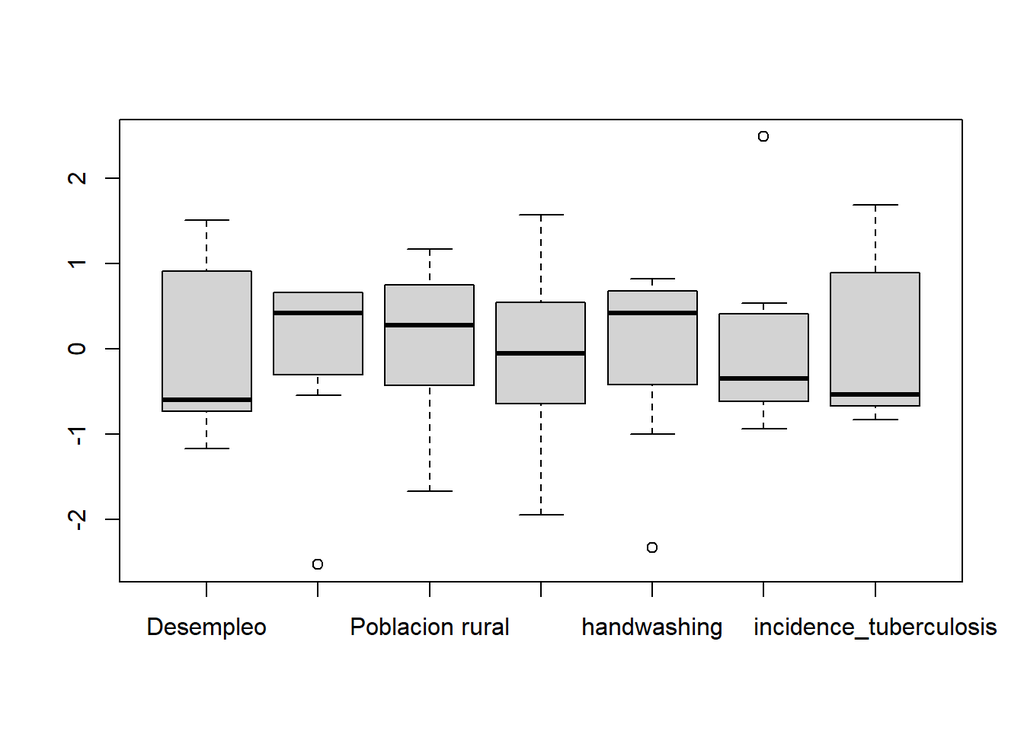

```r
boxplot(normalize(Datamerge[,-1],method='standardize'))
```

–> Nos quedamos con los datos estandarizados

```r
Datamerge[,-1]=normalize(Datamerge[,-1],method='standardize')
Datamerge=Datamerge[complete.cases(Datamerge),]

#descriptivos:
summary(Datamerge)
```

```
##    country            Desempleo        Electricidad      Poblacion rural
##  Length:9           Min.   :-1.1675   Min.   :-0.54909   Min.   :-1.6715
##  Class :character   1st Qu.:-0.7360   1st Qu.:-0.09208   1st Qu.:-0.4280
##  Mode  :character   Median :-0.5954   Median : 0.62324   Median : 0.2274
##                     Mean   : 0.0000   Mean   : 0.28121   Mean   :-0.1301
##                     3rd Qu.: 0.9075   3rd Qu.: 0.66298   3rd Qu.: 0.4455
##                     Max.   : 1.5074   Max.   : 0.66298   Max.   : 1.0553
##     Pobreza          handwashing      mortality_rate     incidence_tuberculosis
##  Min.   :-1.95169   Min.   :-2.3348   Min.   :-0.93653   Min.   :-0.8284
##  1st Qu.:-0.10986   1st Qu.: 0.1438   1st Qu.:-0.62049   1st Qu.:-0.6691
##  Median :-0.01293   Median : 0.4327   Median :-0.44140   Median :-0.6042
##  Mean   : 0.07205   Mean   : 0.1112   Mean   :-0.27636   Mean   :-0.1800
##  3rd Qu.: 0.54716   3rd Qu.: 0.6815   3rd Qu.: 0.06426   3rd Qu.:-0.2679
##  Max.   : 1.57040   Max.   : 0.8220   Max.   : 0.53832   Max.   : 1.6910
```

```r
#Correlaciones para evaluar si es necesario cambiar de monotonía
cor(Datamerge[,-1])
```

```
##                         Desempleo Electricidad Poblacion rural    Pobreza
## Desempleo               1.0000000    0.7510466      -0.3003858  0.1560710
## Electricidad            0.7510466    1.0000000      -0.3061742  0.3003719
## Poblacion rural        -0.3003858   -0.3061742       1.0000000 -0.7453841
## Pobreza                 0.1560710    0.3003719      -0.7453841  1.0000000
## handwashing             0.2219032    0.2935671       0.3697402 -0.6469740
## mortality_rate         -0.7525112   -0.7639475       0.3322423 -0.1247299
## incidence_tuberculosis -0.5665865   -0.7100415       0.2716460 -0.4228974
##                        handwashing mortality_rate incidence_tuberculosis
## Desempleo                0.2219032     -0.7525112             -0.5665865
## Electricidad             0.2935671     -0.7639475             -0.7100415
## Poblacion rural          0.3697402      0.3322423              0.2716460
## Pobreza                 -0.6469740     -0.1247299             -0.4228974
## handwashing              1.0000000     -0.5412622              0.1256422
## mortality_rate          -0.5412622      1.0000000              0.4176589
## incidence_tuberculosis   0.1256422      0.4176589              1.0000000
```

Nótese que la data de desempleo se correlaciona negativamente con la variable Poblacion rural.

```r
Datamerge$`Poblacion rural`=-1*Datamerge$`Poblacion rural`
#ahora:
cor(Datamerge[,-1])
```

```
##                         Desempleo Electricidad Poblacion rural    Pobreza
## Desempleo               1.0000000    0.7510466       0.3003858  0.1560710
## Electricidad            0.7510466    1.0000000       0.3061742  0.3003719
## Poblacion rural         0.3003858    0.3061742       1.0000000  0.7453841
## Pobreza                 0.1560710    0.3003719       0.7453841  1.0000000
## handwashing             0.2219032    0.2935671      -0.3697402 -0.6469740
## mortality_rate         -0.7525112   -0.7639475      -0.3322423 -0.1247299
## incidence_tuberculosis -0.5665865   -0.7100415      -0.2716460 -0.4228974
##                        handwashing mortality_rate incidence_tuberculosis
## Desempleo                0.2219032     -0.7525112             -0.5665865
## Electricidad             0.2935671     -0.7639475             -0.7100415
## Poblacion rural         -0.3697402     -0.3322423             -0.2716460
## Pobreza                 -0.6469740     -0.1247299             -0.4228974
## handwashing              1.0000000     -0.5412622              0.1256422
## mortality_rate          -0.5412622      1.0000000              0.4176589
## incidence_tuberculosis   0.1256422      0.4176589              1.0000000
```

```r
#cambio de monotonia
Datamerge$mortality_rate=-1*Datamerge$mortality_rate
#ahora:
cor(Datamerge[,-1])
```

```
##                         Desempleo Electricidad Poblacion rural    Pobreza
## Desempleo               1.0000000    0.7510466       0.3003858  0.1560710
## Electricidad            0.7510466    1.0000000       0.3061742  0.3003719
## Poblacion rural         0.3003858    0.3061742       1.0000000  0.7453841
## Pobreza                 0.1560710    0.3003719       0.7453841  1.0000000
## handwashing             0.2219032    0.2935671      -0.3697402 -0.6469740
## mortality_rate          0.7525112    0.7639475       0.3322423  0.1247299
## incidence_tuberculosis -0.5665865   -0.7100415      -0.2716460 -0.4228974
##                        handwashing mortality_rate incidence_tuberculosis
## Desempleo                0.2219032      0.7525112             -0.5665865
## Electricidad             0.2935671      0.7639475             -0.7100415
## Poblacion rural         -0.3697402      0.3322423             -0.2716460
## Pobreza                 -0.6469740      0.1247299             -0.4228974
## handwashing              1.0000000      0.5412622              0.1256422
## mortality_rate           0.5412622      1.0000000             -0.4176589
## incidence_tuberculosis   0.1256422     -0.4176589              1.0000000
```

```r
Datamerge$incidence_tuberculosis=-1*Datamerge$incidence_tuberculosis
#ahora:
cor(Datamerge[,-1])
```

```
##                        Desempleo Electricidad Poblacion rural    Pobreza
## Desempleo              1.0000000    0.7510466       0.3003858  0.1560710
## Electricidad           0.7510466    1.0000000       0.3061742  0.3003719
## Poblacion rural        0.3003858    0.3061742       1.0000000  0.7453841
## Pobreza                0.1560710    0.3003719       0.7453841  1.0000000
## handwashing            0.2219032    0.2935671      -0.3697402 -0.6469740
## mortality_rate         0.7525112    0.7639475       0.3322423  0.1247299
## incidence_tuberculosis 0.5665865    0.7100415       0.2716460  0.4228974
##                        handwashing mortality_rate incidence_tuberculosis
## Desempleo                0.2219032      0.7525112              0.5665865
## Electricidad             0.2935671      0.7639475              0.7100415
## Poblacion rural         -0.3697402      0.3322423              0.2716460
## Pobreza                 -0.6469740      0.1247299              0.4228974
## handwashing              1.0000000      0.5412622             -0.1256422
## mortality_rate           0.5412622      1.0000000              0.4176589
## incidence_tuberculosis  -0.1256422      0.4176589              1.0000000
```

```r
# Preparando la data
#Se elimina la columna pais para quedarnos solo con numericas
dataClus=Datamerge[,-1]
row.names(dataClus)=Datamerge$country
```

```r
#Distancia entre casos (paises)
library(cluster)
g.dist = daisy(dataClus, metric="gower")
```

# Partición

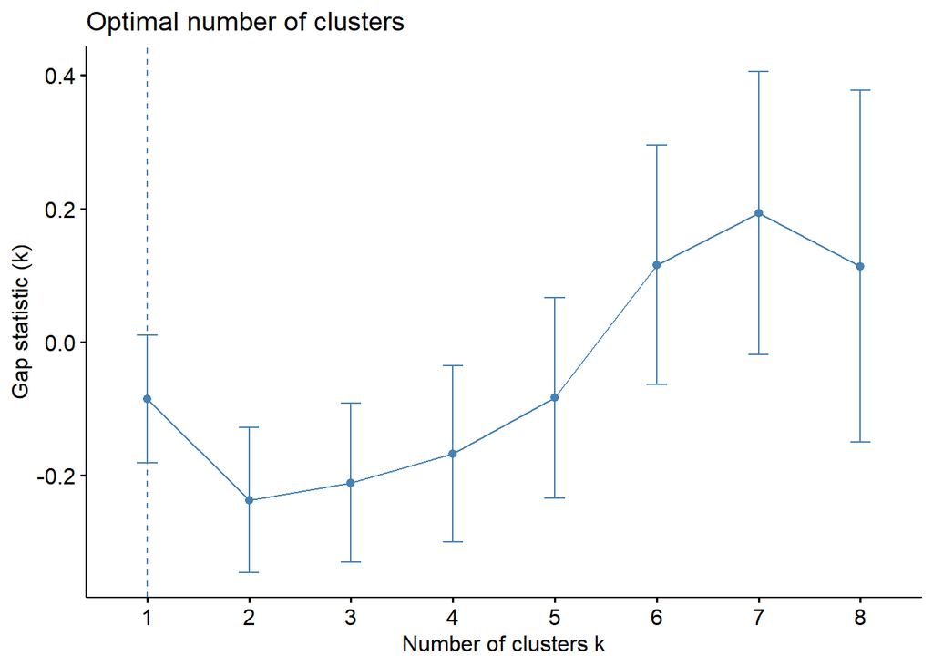

```r
#Proponer cantidad de clusters
## para PAM

library(factoextra)
fviz_nbclust(dataClus, pam,diss=g.dist,method = "gap_stat",k.max = 8,verbose = F)
```

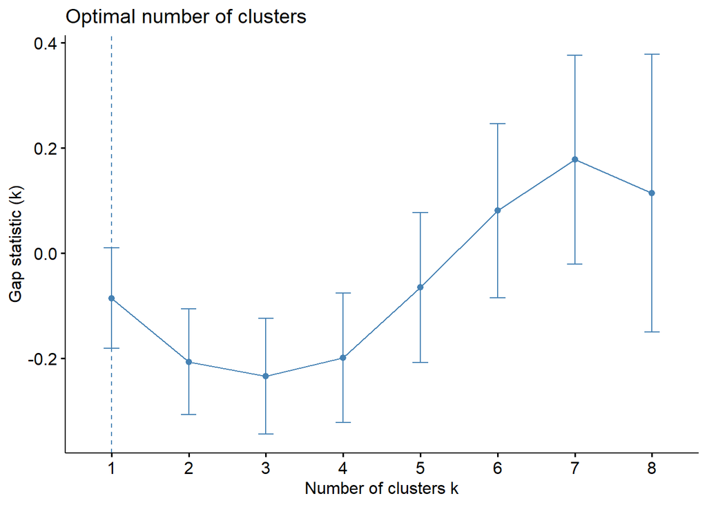

```r
## PARA JERARQUICO

fviz_nbclust(dataClus, hcut,diss=g.dist,method = "gap_stat",k.max = 8,verbose = F,hc_func = "agnes")
```

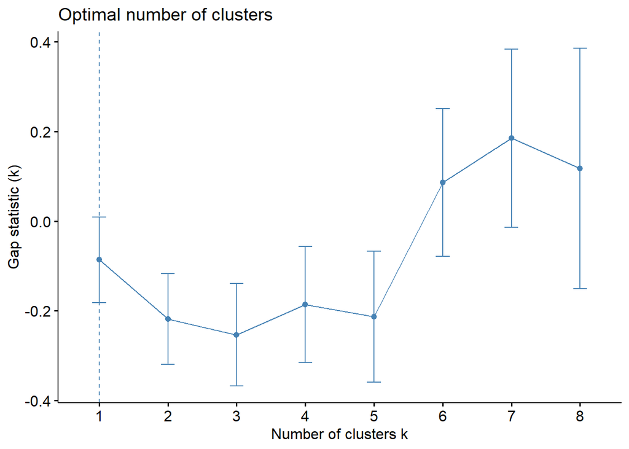

```r
## PARA JERARQUICO DIANA

fviz_nbclust(dataClus, hcut,diss=g.dist,method = "gap_stat",k.max = 8,verbose = F,hc_func = "diana")
```

# EVALUANDO RESULTADOS

```r
###pam
set.seed(123)
grupos=3 # 3 grupos
res.pam=pam(g.dist,k = grupos,cluster.only = F)
dataClus$pam=res.pam$cluster

###agnes
res.agnes<- hcut(g.dist, k =grupos,hc_func='agnes',hc_method = "ward.D")
dataClus$agnes=res.agnes$cluster

### diana
res.diana <- hcut(g.dist, k = grupos,hc_func='diana')
dataClus$diana=res.diana$cluster
```

#Determinar el mejor

```
##   cluster size ave.sil.width
## 1       1    4          0.43
## 2       2    4          0.08
## 3       3    1          0.00
```

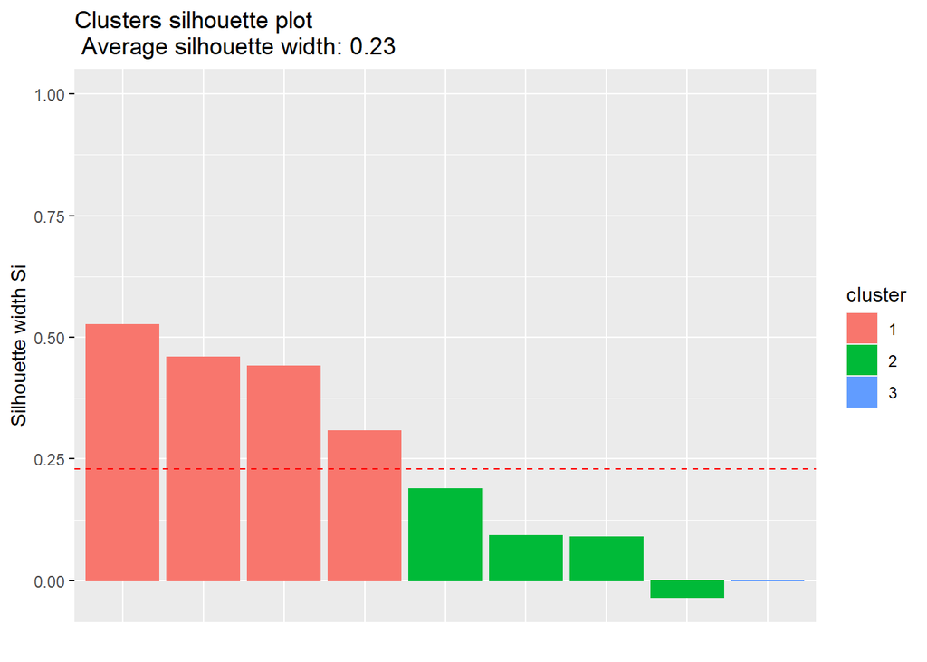

```r
fviz_silhouette(res.pam)
```

```
##   cluster size ave.sil.width
## 1       1    4          0.43
## 2       2    4          0.08
## 3       3    1          0.00
```

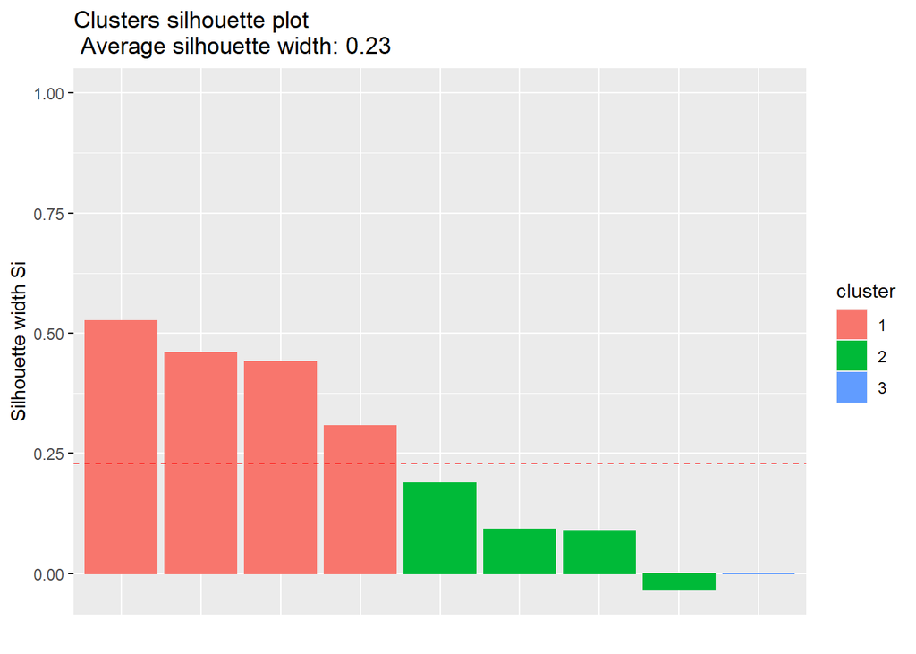

```r
fviz_silhouette(res.agnes)
```

```
##   cluster size ave.sil.width
## 1       1    6          0.42
## 2       2    1          0.00
## 3       3    2          0.20
```

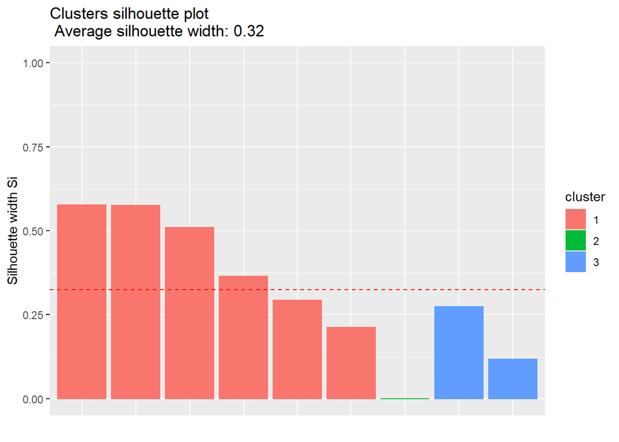

```r
fviz_silhouette(res.diana)
```

```r
# Resultados mal clusterizados
library(magrittr)
```

```r
silPAM=data.frame(res.pam$silinfo$widths)
silPAM$country=row.names(silPAM)
poorPAM=silPAM[silPAM$sil_width<0,'country']%>%sort()

silAGNES=data.frame(res.agnes$silinfo$widths)
silAGNES$country=row.names(silAGNES)
poorAGNES=silAGNES[silAGNES$sil_width<0,'country']%>%sort()

silDIANA=data.frame(res.diana$silinfo$widths)
silDIANA$country=row.names(silDIANA)
poorDIANA=silDIANA[silDIANA$sil_width<0,'country']%>%sort()

###
#install.packages('qpcR')
library("qpcR")
mal_Clus=as.data.frame(qpcR:::cbind.na(poorPAM, poorAGNES,poorDIANA))
mal_Clus
```

| poorPAM | poorAGNES | poorDIANA |
| --- | --- | --- |
| Paraguay | Paraguay | NA |

```r
# Teoría de conjuntos para ver qué los casos mal clusterizados en todos las técnicas:
intersect(poorPAM,poorAGNES)
```

```
## [1] "Paraguay"
```

```r
#Tecnica PAM
original=aggregate(.~ pam, data=dataClus,mean)
original[order(original$Desempleo),]
```

|  | pam | Desempleo | Electricidad | Poblacion rural | Pobreza | handwashing | mortality_rate | incidence_tuberculosis | agnes | diana |
| --- | --- | --- | --- | --- | --- | --- | --- | --- | --- | --- |
| 3 | 3 | -1.1674614 | -0.5490943 | -1.055273862 | -1.9516920 | 0.7937047 | -0.41190388 | -0.88857780 | 3 | 3.00 |
| 2 | 2 | -0.7150846 | 0.1169609 | 0.005462524 | 0.4044483 | -0.3218714 | 0.03055042 | -0.05369228 | 2 | 1.75 |
| 1 | 1 | 1.0069500 | 0.6530414 | 0.550972306 | 0.2455771 | 0.3736796 | 0.69423186 | 0.68088896 | 1 | 1.00 |

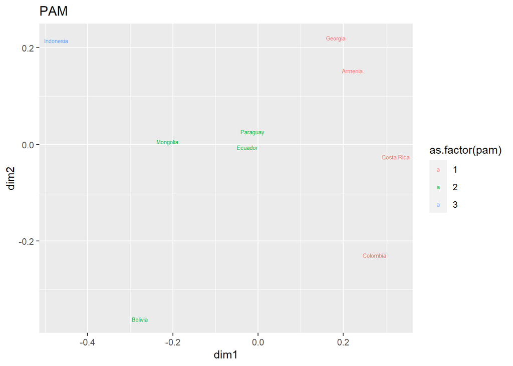

```r
library(ggplot2)
proyeccion = cmdscale(g.dist, k=3,add = T) # k es la cantidad de dimensiones
dataClus$dim1 <- proyeccion$points[,1]
dataClus$dim2 <- proyeccion$points[,2]
base= ggplot(dataClus,aes(x=dim1, y=dim2,label=row.names(dataClus)))
base + geom_text(size=2, aes(color=as.factor(pam)))  + labs(title = "PAM")
```

```r
set.seed(123)
pam.resultado=pam(g.dist,3,cluster.only = F)

#nueva columna
dataClus$pam=pam.resultado$cluster
```

```r
#resultados
aggregate(.~ pam, data=dataClus,mean)
```

| pam | Desempleo | Electricidad | Poblacion rural | Pobreza | handwashing | mortality_rate | incidence_tuberculosis | agnes | diana | dim1 | dim2 |
| --- | --- | --- | --- | --- | --- | --- | --- | --- | --- | --- | --- |
| 1 | 1.0069500 | 0.6530414 | 0.550972306 | 0.2455771 | 0.3736796 | 0.69423186 | 0.68088896 | 1 | 1.00 | 0.2501300 | 0.02970274 |
| 2 | -0.7150846 | 0.1169609 | 0.005462524 | 0.4044483 | -0.3218714 | 0.03055042 | -0.05369228 | 2 | 1.75 | -0.1317210 | -0.08349072 |
| 3 | -1.1674614 | -0.5490943 | -1.055273862 | -1.9516920 | 0.7937047 | -0.41190388 | -0.88857780 | 3 | 3.00 | -0.4736359 | 0.21515193 |

```r
#Recodificar
original=aggregate(.~ pam, data=dataClus,mean)
original[order(original$Desempleo),]
```

|  | pam | Desempleo | Electricidad | Poblacion rural | Pobreza | handwashing | mortality_rate | incidence_tuberculosis | agnes | diana | dim1 | dim2 |
| --- | --- | --- | --- | --- | --- | --- | --- | --- | --- | --- | --- | --- |
| 3 | 3 | -1.1674614 | -0.5490943 | -1.055273862 | -1.9516920 | 0.7937047 | -0.41190388 | -0.88857780 | 3 | 3.00 | -0.4736359 | 0.21515193 |
| 2 | 2 | -0.7150846 | 0.1169609 | 0.005462524 | 0.4044483 | -0.3218714 | 0.03055042 | -0.05369228 | 2 | 1.75 | -0.1317210 | -0.08349072 |
| 1 | 1 | 1.0069500 | 0.6530414 | 0.550972306 | 0.2455771 | 0.3736796 | 0.69423186 | 0.68088896 | 1 | 1.00 | 0.2501300 | 0.02970274 |

# Estrategia Jerárquica

–> Metodo Aglomerativo

```r
# metodo jerarquico--> algoritmo AGNES
set.seed(123)
library(factoextra)

res.agnes<- hcut(g.dist, k = 3,hc_func='agnes',hc_method = "ward.D")

dataClus$agnes=res.agnes$cluster
```

```r
aggregate(.~ agnes, data=dataClus,mean)
```

| agnes | Desempleo | Electricidad | Poblacion rural | Pobreza | handwashing | mortality_rate | incidence_tuberculosis | pam | diana | dim1 | dim2 |
| --- | --- | --- | --- | --- | --- | --- | --- | --- | --- | --- | --- |
| 1 | 1.0069500 | 0.6530414 | 0.550972306 | 0.2455771 | 0.3736796 | 0.69423186 | 0.68088896 | 1 | 1.00 | 0.2501300 | 0.02970274 |
| 2 | -0.7150846 | 0.1169609 | 0.005462524 | 0.4044483 | -0.3218714 | 0.03055042 | -0.05369228 | 2 | 1.75 | -0.1317210 | -0.08349072 |
| 3 | -1.1674614 | -0.5490943 | -1.055273862 | -1.9516920 | 0.7937047 | -0.41190388 | -0.88857780 | 3 | 3.00 | -0.4736359 | 0.21515193 |

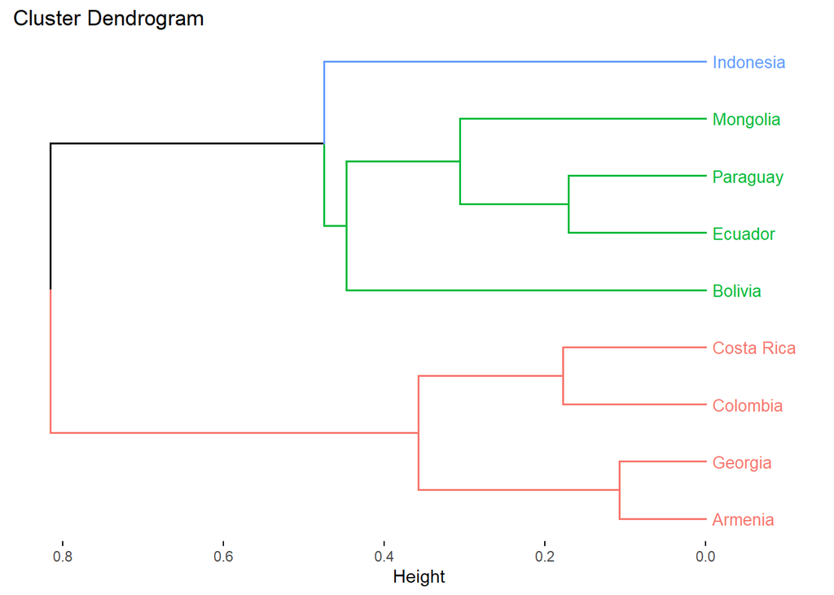

```r
#Visualizar
fviz_dend(res.agnes, cex = 0.7, horiz = T)
```

```r
#Comparando
table(dataClus$pam,dataClus$agnes,dnn = c('Particion','Aglomeracion'))
```

```
##          Aglomeracion
## Particion 1 2 3
##         1 4 0 0
##         2 0 4 0
##         3 0 0 1
```

# Estrategia Divisiva (ESTRATEGIA ESCOGIDA EN EL ANÁLISIS)

```r
set.seed(123)
res.diana <- hcut(g.dist, k = 3,hc_func='diana')
dataClus$diana=res.diana$cluster
```

```r
aggregate(.~ diana, data=dataClus,mean)
```

| diana | Desempleo | Electricidad | Poblacion rural | Pobreza | handwashing | mortality_rate | incidence_tuberculosis | pam | agnes | dim1 | dim2 |
| --- | --- | --- | --- | --- | --- | --- | --- | --- | --- | --- | --- |
| 1 | 0.4164764 | 0.5801846 | 0.2551635 | 0.2366014 | 0.3515569 | 0.53094516 | 0.6553212 | 1.333333 | 1.333333 | 0.1604422 | 0.02325944 |
| 2 | -0.5953727 | -0.3090148 | 0.4280243 | 1.1934187 | -2.3348131 | -0.53831940 | 0.2678714 | 2.000000 | 2.000000 | -0.2773210 | -0.36084616 |
| 3 | -0.9517429 | -0.3205891 | -0.3942699 | -0.9823085 | 0.6132045 | -0.08006316 | -1.2897949 | 2.500000 | 2.500000 | -0.3426661 | 0.11064475 |

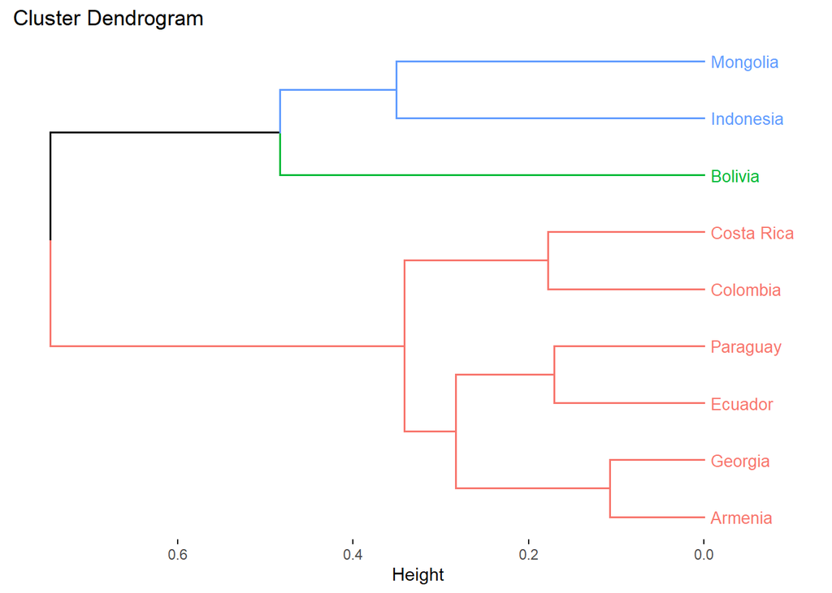

```r
fviz_dend(res.diana, cex = 0.7, horiz = T)
```

```r
#Comparando
table(dataClus$diana,dataClus$agnes,dnn = c('Division','Aglomeracion'))
```

```
##         Aglomeracion
## Division 1 2 3
##        1 4 2 0
##        2 0 1 0
##        3 0 1 1
```

## ESTRATEGIA BASADA EN DENSIDAD

La estrategia basada en densidad sigue una estrategia muy sencilla: juntar a los casos cuya cercanía entre sí los diferencia de otros.

```r
proyeccion = cmdscale(g.dist, k=3,add = T) # k es la cantidad de dimensiones
```

```r
dataClus$dim1 <- proyeccion$points[,1]
dataClus$dim2 <- proyeccion$points[,2]
```

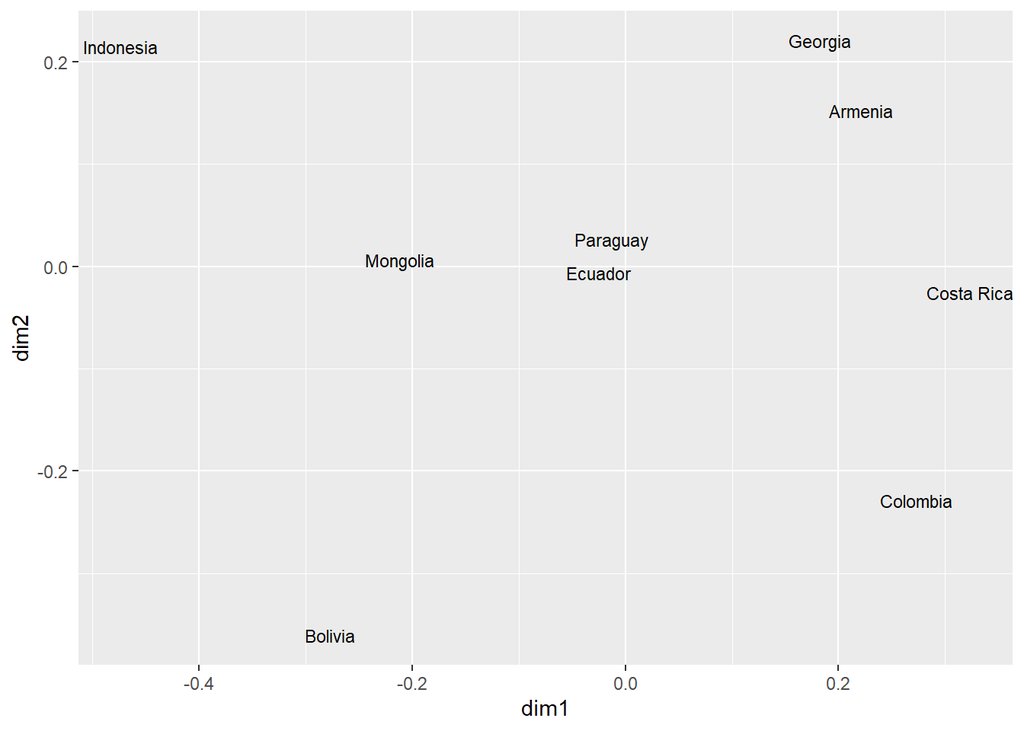

```r
base= ggplot(dataClus,aes(x=dim1, y=dim2,label=row.names(dataClus)))
base + geom_text(size=3)
```

- PAM

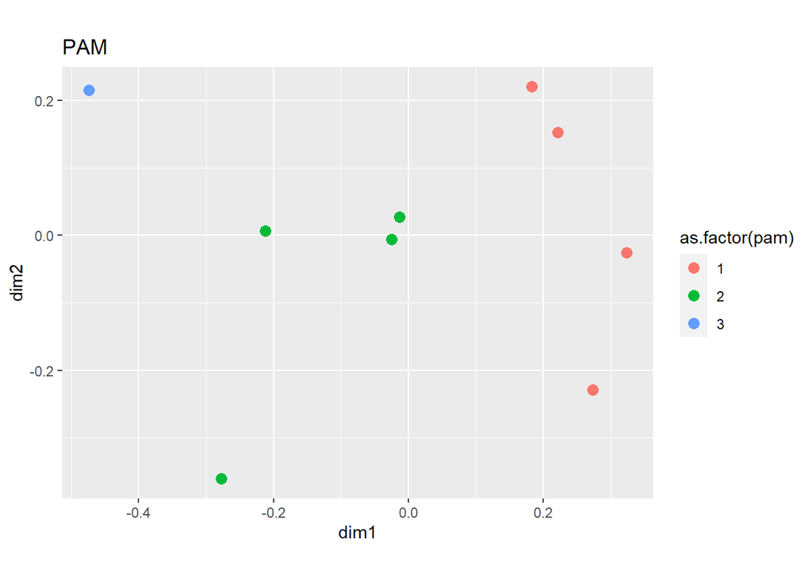

```r
base= ggplot(dataClus,aes(x=dim1, y=dim2)) +  coord_fixed()
base + geom_point(size=3, aes(color=as.factor(pam)))  + labs(title = "PAM")
```

- AGNES

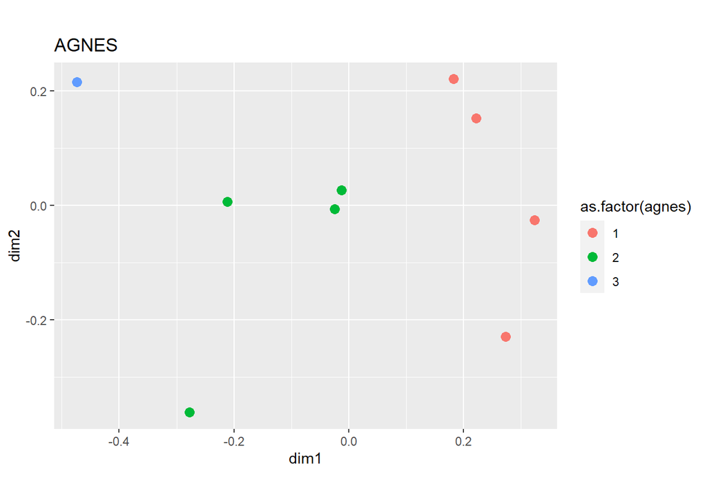

```r
base + geom_point(size=3, aes(color=as.factor(agnes))) + labs(title = "AGNES")
```

- DIANA

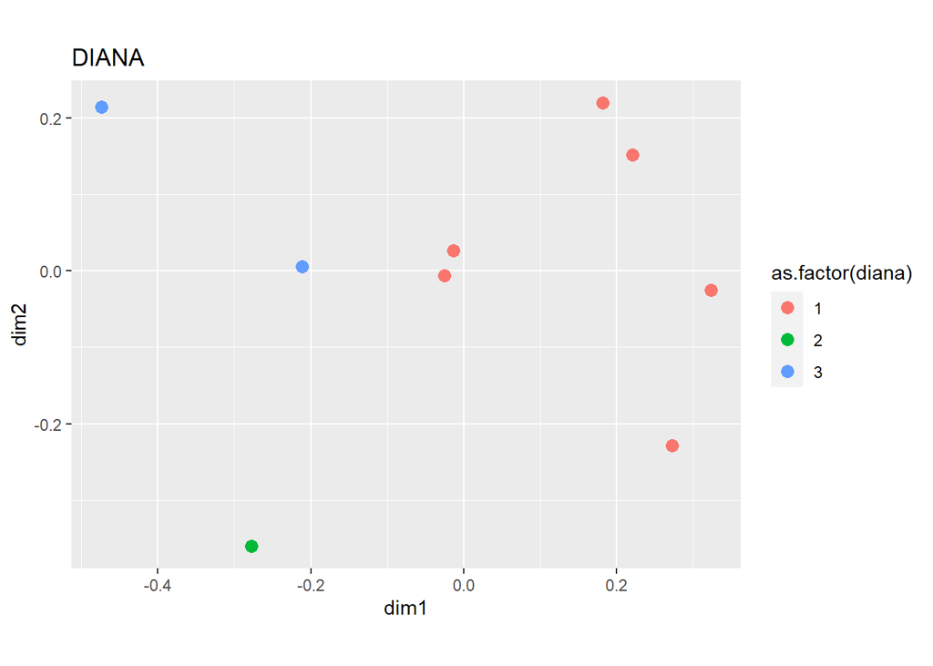

```r
base + geom_point(size=3, aes(color=as.factor(diana))) + labs(title = "DIANA")
```

```r
#Nuevas distancias: Las posiciones son la información para dbscan.

library(cluster)
g.dist = daisy(dataClus, metric="gower")
g.dist.cmd = daisy(dataClus[,c('dim1','dim2')], metric = 'euclidean')
```

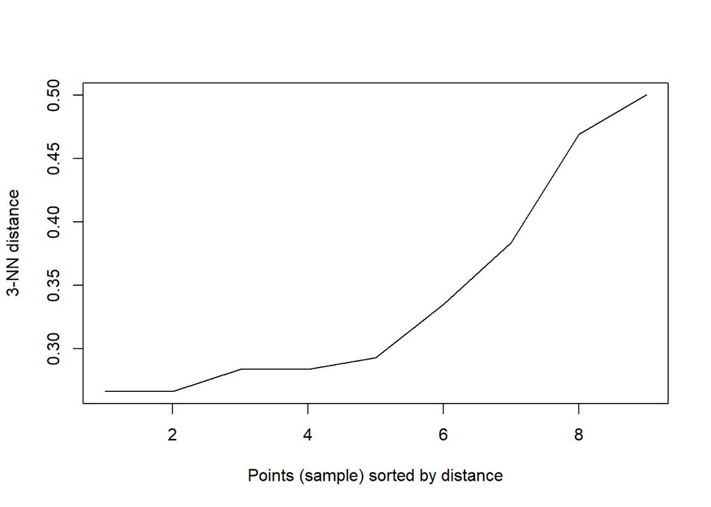

```r
library(dbscan)
kNNdistplot(g.dist.cmd, k=3)
```

```r
#Obteniendo clusters
#install.packages('fpc')
library(fpc)
db.cmd = fpc::dbscan(g.dist.cmd, eps=0.30, MinPts=7,method = 'dist')
```

```r
db.cmd
```

```
## dbscan Pts=9 MinPts=7 eps=0.3
##
## 0
## 9
```

```r
dataClus$db=as.factor(db.cmd$cluster)
```

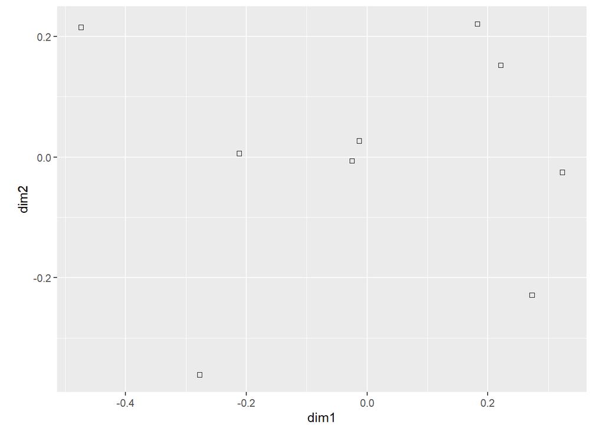

```r
library(ggrepel)
base= ggplot(dataClus[dataClus$db!=0,],aes(x=dim1, y=dim2)) + coord_fixed()

dbplot= base + geom_point(aes(color=db))

dbplot + geom_point(data=dataClus[dataClus$db==0,],
                    shape=0)
```

# Anexo Proceso del Analisis Factorial Exploratorio (EFA)

```r
Datamerge[,-1]=lapply(Datamerge[,-1],as.numeric)

# sin perdidos:
Datamerge=na.omit(Datamerge)
```

```r
dontselect=c("country")
select=setdiff(names(Datamerge),dontselect)
theData=Datamerge[,select] # sin los Scores ni nombre de país.


# esta es:
#install.packages('polycor')
library(polycor)
corMatrix=polycor::hetcor(theData)$correlations
```

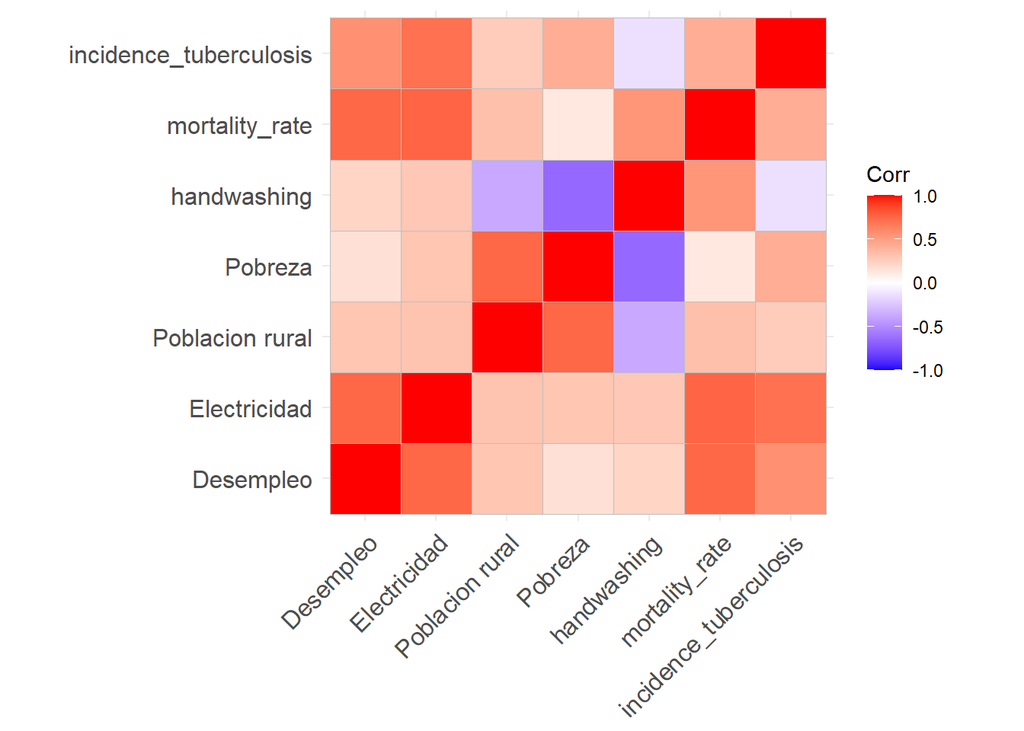

```r
#install.packages('ggcorrplot')
library(ggcorrplot)

ggcorrplot(corMatrix)
```

# Hay bloques correlacionados, hay esperanza

```r
#Verificar si datos permiten factorizar
library(psych)
psych::KMO(corMatrix)
```

```
## Kaiser-Meyer-Olkin factor adequacy
## Call: psych::KMO(r = corMatrix)
## Overall MSA =  0.57
## MSA for each item =
##              Desempleo           Electricidad        Poblacion rural
##                   0.59                   0.67                   0.77
##                Pobreza            handwashing         mortality_rate
##                   0.47                   0.36                   0.58
## incidence_tuberculosis
##                   0.73
```

–> KMO debería pasar de 0.6 - VALORES PREOCUPANTES: Handwashing / Pobreza / Mortality rate /desempleo

Aplicando las dos pruebas:

–> Matriz identidad

```r
cortest.bartlett(corMatrix,n=nrow(theData))$p.value>0.05
```

```
## [1] TRUE
```

INTERPRETACIÓN: Si tenemos una matriz de identidad

–> Matriz singular

```r
library(matrixcalc)

is.singular.matrix(corMatrix)
```

```
## [1] FALSE
```

INTERPRETACIÓN: No tenemos una matriz singular

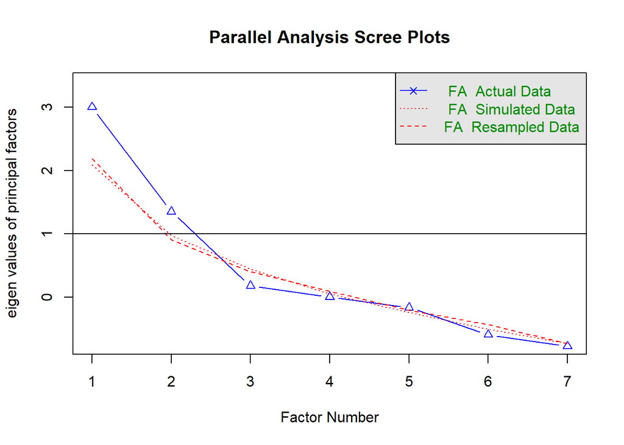

```
## Parallel analysis suggests that the number of factors =  2  and the number of components =  NA
```

```r
#Determinar en cuantos factores o variables latentes podríamos redimensionar la data:
fa.parallel(theData,fm = 'ML', fa = 'fa',correct = T)
```

# Parallel analysis suggests that the number of factors = 2 and the number of components = NA

# ANALISIS FACTORIAL CONFIRMATORIO

```r
model <- ' desempleo  =~ Electricidad + Poblacion Rural + Pobreza + handwashing + mortality_rate + indicende_tuberculosis'
```

```r
# normalizar las variables:
#install.packages('lavaan')
theDataNorm=as.data.frame(scale(theData))
library(lavaan)
```